# SPPH 604 001 Lab Exercise: Data wrangling

Belal Hossain and Ehsan Karim

School of Population and Public Health, UBC

# Problem

Use the functions we learned in Lab 1 to complete Lab 1 Exercise. We will use Right Heart Catheterization Dataset saved in the folder named ‘Data/wrangling/’. The variable list and description can be accessed from this website (https://biostat.app.vumc.org/wiki/pub/Main/DataSets/rhc.html).

A paper you can access the original table from [this paper](https://jamanetwork-com.ezproxy.library.ubc.ca/journals/jama/fullarticle/407990) ([doi: 10.1001/jama.1996.03540110043030](https://pubmed.ncbi.nlm.nih.gov/8782638/)). We have modified the table and corrected some mistakes. Please knit your file once you finished and submit the knitted file **ONLY**.

```r
# Load required packages
library(dplyr)
library(tableone)
```

```r
# Data import: name it rhc
#rhc <- ...("Data/wrangling/rhc.csv", ...)
```

## Part (a) Basic Manipulation [60%]

1. Continuous to Categories: Change the Age variable into categories below 50, 50 to below 60, 60 to below 70, 70 to below 80, 80 and above [Hint: the `cut` function could be helpful]
2. Re-order: Re-order the levels of race to white, black and other
3. Set reference: Change the reference category for gender to Male
4. Count levels: Check how many levels does the variable “cat1” (Primary disease category) have? Regroup the levels for disease categories to “ARF”,“CHF”,“MOSF”,“Other”. [Hint: the `nlevels` and `list` functions could be helpful]
5. Rename levels: Rename the levels of “ca” (Cancer) to “Metastatic”,“None” and “Localized (Yes)”, then re-order the levels to “None”,“Localized (Yes)” and “Metastatic”
6. comorbidities:
- create a new variable called “numcom” to count number of comorbidities illness for each person (12 categories) [Hint: the `rowSums` command could be helpful],
- report maximim and minimum values of numcom:
7. Anlaytic data: Create a dataset that has only the following variables
- “age”, “sex”, “race”,“cat1”, “ca”, “dnr1”, “aps1”, “surv2md1”, “numcom”, “adld3p”, “das2d3pc”, “temp1”, “hrt1”, “meanbp1”, “resp1”, “wblc1”, “pafi1”, “paco21”, “ph1”, “crea1”, “alb1”, “scoma1”, “swang1”, and
- name it rhc2.

## Optional 1: Missing values

1. Any variables included in rhc2 data had missing values? Name that variable. [Hint: `apply` function could be helpful]
2. Count how many NAs does that variable have?
3. Produce a table 1 for a complete case data (no missing observations) stratified by `swang1`.

## Optional 2: Calculating variance of a sample

Write a `function` for Bessel’s correction to calculate an unbiased estimate of the population variance from a finite sample (a vector of 100 observations, consisting of numbers from 1 to 100).

```r
Vector <- 1:100

#variance.est <- function(?){?}

#variance.est(Vector)
```

Hint: Take a closer look at the functions, loops and algorithms shown in lab materials. Use a `for loop`, utilizing the following pseudocode of the [algorithm](https://en.wikipedia.org/wiki/Algorithms_for_calculating_variance):

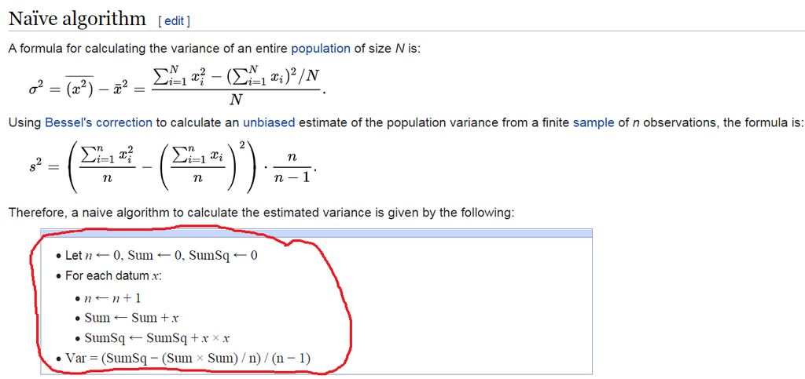

Verify that estimated variance with the following variance function output in R:

```r
var(Vector)
```

```
## [1] 841.6667
```

# Knit your file

Please knit your file once you finished and submit the knitted PDF or doc file. Please also fill-up the following table:

[output not shown]